# Finance 6470: Derivatives Markets

Dan Wouden

Due Date: April 12, 2017

**1.** In class we stated that the equilibrium price of a forward contract should behave according to the formula $F_{0} = S_{0}e^{rT}$. Demonstrate that this is true using the arbitrage principle. Assume that you are dealing with an investment asset that pays no dividends unless stated otherwise. Specifically, answer the following:

1. Suppose $F_{0} > S_{0} e^{rT}$. Does this imply an arbitrage opportunity? Explain.

| **Transaction** | **CF Time 0** | **CF Time T (expiration)** |
| --- | --- | --- |
| Buy asset at $S_{0}$ | $-S_{0}$ | $+S_{T}$ |
| Borrow $S_{0}$ at r | $+S_{0}$ | $-S_{0}e^{rT}$ |
| Sell prepaid forward, $F_{0}$ | $+F_{0}$ | $-S_{T}$ |
| **Sub-Total** | $F_{0}$ | $-S_{0}e^{rT}$ |
| **Net Cash Flow** | $F_{0}-S_{0}e^{rT}>0$ |  |

Yes, there is an arbitrage opportunity. The arbitrageur takes a short position in the forward,(sells the forward contract for $F_{0}$), borrows $S_{0}$ for T years at the spot interest rate of r at time 0, buys asset for $S_{0}$ at time 0, he waits T years, delivers the asset and collects $F_{0}$, uses $S_{0}e^{rt}$ to repay loan. Therefore, the arbitrageur earns $F_{0}-S_{0}e^{rT}>0$, he makes the difference. This transaction is risk-free and has a positive return, this is a true arbitrage opportunity. Please refer to the above table for a summary.

2. Now suppose $F_{0} < S_{0} e^{rT}$. Does this imply an arbitrage opportunity? Explain.

| **Transaction** | **CF Time 0** | **CF Time T (expiration)** |
| --- | --- | --- |
| Buys forward | $-F_{0}$ | $S_{T}$ |
| Sells asset | $+S_{0}$ | $-S_{T}$ |
| Invests $S_{0}$ at r | $-S_{0}$ | $+S_{0}e^{rT}$ |
| **Sub-Total** | $-F_{0}$ | $+S_{0}e^{rT}$ |
| **Net Cash Flow** | $S_{0}e^{rT}-F_{0}>0$ |  |

Yes, there is an arbitrage opportunity. The arbitrageur takes a long position in the forward contract(buys the forward contract for $F_{0}$), short sells the asset for $S_{0}$, deposits $S_{0}$ for T years at spot interest rate r, he waits T years, and withdraws $S_{0}e^{rt}$ from his original deposit, and finally has the asset delivered to him for $F_{T}$ and uses it to close his short position on the asset. Therefore, the arbitrageur, earns $S_{0}e^{rt}-F_{0}>0$, he makes the difference. As above, this is a risk-free, positive return transaction which is an arbitrage. Please refer to the above table for a summary.

3. Now assume that you are dealing with either a dividend-paying asset in the form of discrete dollar dividend payments, or a continuous dividend yield. How does this change the pricing equation? Explain.

**Discrete Dividends**

The pricing equation is the following for discrete dividends:

$F_{0,T}=S_{0}-\sum_{i=1}^{n}PV_{0,t_{i}}(D_{t_{i}})$

where $PV_{0,t_{i}}$ is the present value at time 0, of the payment at time $t_i$.

The pricing equation changes by including the present value of the dividends over the life of the forward contract. We do this since the forward price is less than the asset price, when the asset pays a dividend. To explain, the asset owner receives the dividends and the forward contract owner does not. Thus, the forward contract price is adjusted to reflect the dividends that the asset owner receives. The price of the forward contract will be the asset price less the present value of dividends to be paid over the life of the contract.

**Continuous Dividends**

$F_{0,T}=S_{0}e^{-\delta*T}$

where $\delta$ is the dividend yield and T is time of maturity.

The pricing equation refer to page 161.

4. Now assume that you are dealing with a consumption commodity with storage costs, and that holding the physical commodity has certain benefits (i.e. a convenience yield). How does this change the pricing equation? Explain.

$F_{0,T}=S_{0}e^{(r+\lambda-c)*(T)}$

where continuous storage costs of $\lambda$ are paid continuously and are proportional to the value of the commodity, continuously compounded convenience yield is c, proportional to the value of the commodity.With this change to the forward pricing formula, it makes it possible for backwardation to happen. Note: in the real world the non-arbitrage relationship doesn’t really hold since its difficult to short the underlying.  
The pricing equation refer to page 161.

5. In class we argued that all of this depends upon the possibility of physical delivery of the contract, which guarantees that $F_{T} = S_{T}$, that is that the futures price at maturity is equal to the spot price at maturity. First, explain why that is. Second, what would happen if $F_{T} \ne S_{T}$? Carefully explain.

The convergence of these prices at maturity, $F_{T} = S_{T}$. The futures price at maturity is equal to the spot price at maturity. This convergence can be easily explained by arbitrage and the law of one price.

For example, suppose the futures contract for corn is priced higher than the spot price as time approaches the contract’s month of delivery. In this situation, traders will have the arbitrage opportunity of shorting futures contracts, buying the underlying asset and then making delivery. In this situation, the trader locks in profit because the amount of money received by shorting the contracts already exceeds the amount spent buying the underlying asset to cover the position.

In terms of supply and demand, the effect of arbitrageurs shorting futures contracts causes a drop in futures prices because it creates an increase in the supply of contracts available for trade. Subsequently, buying the underlying asset will causes an increase in the overall demand for the asset and the spot price of the underlying asset will increase as a result .

As arbitragers continue to do this, the futures prices and spot prices will slowly converge until they are more or less equal. The same sort of effect occurs when spot prices are higher than futures except that arbitrageurs would short sell the underlying asset and long the futures contracts.

6. Consider a new kind of forward contract called a *prepaid forward*. It is very similar to a standard forward contract. The only difference is that the long party pays the short party at time $t = 0$, but still takes delivery from the short party at $t = T$. How must the standard pricing formula be modified to properly price the prepaid forward? Carefully explain your logic. Why would anyone ever want to transact in such a contract? Do we actually see prepaid forward contracts in the real world, or only in finance textbooks?

If there are no dividends then $F_{0,T}^{P} = S_{0}$ If there are dividends then $F_{0,T}^{P} = S_{0}-PV_i$ Where $PV_i$ are cash flow of the underlying over the length of the contract discounted back to time 0.

This could also be an instrument to defer taxes, since the time of ownership could keep on changing. It seems like there is a lot of risk in this type of contract. There is a high chance of default, flight risk. Take the money and run. This is only seen in finance textbooks.

**2.** In the Midterm folder on Canvas there is a sub-folder titled Data. In it you will find historical nearby daily settlement prices for the Class III Milk (ticker symbol DL) and Cheese (ticker symbol BJ) futures traded on the CME for the period January 1, 2016 - December 31, 2016. Using these data answer the following questions:

1. Test the series for unit roots using the Augmented Dickey-Fuller test. Conduct the tests for prices in levels, and first price differences. Also conduct the test in log-price levels and log-price first differences. What do you conclude? Do any of the series contain a unit root? Which ones? Are the results what you expected, or did they surprise you?

2.a Conclusion

[output not shown]

```r
chooseCRANmirror(graphics=FALSE, ind=1)
knitr::opts_chunk$set(echo = TRUE)
raw.data = read.csv("C:/Users/Daniel/Desktop/Tyler Brough FIN 6470/dairy.csv")
head(raw.data)
```

```
##        Date DL.Nearest.Settlement BJ.Nearest.Settlement
## 1  1/4/2016                 13.56                 1.505
## 2  1/5/2016                 13.50                 1.496
## 3  1/6/2016                 13.52                 1.500
## 4  1/7/2016                 13.57                 1.501
## 5  1/8/2016                 13.68                 1.509
## 6 1/11/2016                 13.72                 1.513
```

```r
##look at Data
summary(raw.data)
```

```
##         Date     DL.Nearest.Settlement BJ.Nearest.Settlement
##  1/11/2016:  1   Min.   :12.73         Min.   :1.407
##  1/12/2016:  1   1st Qu.:13.72         1st Qu.:1.515
##  1/13/2016:  1   Median :14.71         Median :1.575
##  1/14/2016:  1   Mean   :14.92         Mean   :1.611
##  1/15/2016:  1   3rd Qu.:16.68         3rd Qu.:1.757
##  1/19/2016:  1   Max.   :17.39         Max.   :1.836
##  (Other)  :242
```

```r
install.packages("urca")
library(urca)
##ADF Test for class 3 milk, level prices
adf.dl <- ur.df(y=raw.data$DL.Nearest.Settlement, type = "drift", selectlags = "BIC")
summary(adf.dl)
```

```
##
## ###############################################
## # Augmented Dickey-Fuller Test Unit Root Test #
## ###############################################
##
## Test regression drift
##
##
## Call:
## lm(formula = z.diff ~ z.lag.1 + 1 + z.diff.lag)
##
## Residuals:
##      Min       1Q   Median       3Q      Max
## -1.41227 -0.03780 -0.01923  0.01191  1.87100
##
## Coefficients:
##              Estimate Std. Error t value Pr(>|t|)
## (Intercept)  0.140470   0.142299   0.987    0.325
## z.lag.1     -0.008432   0.009499  -0.888    0.376
## z.diff.lag   0.070251   0.064215   1.094    0.275
##
## Residual standard error: 0.227 on 243 degrees of freedom
## Multiple R-squared:  0.007393,   Adjusted R-squared:  -0.0007765
## F-statistic: 0.9049 on 2 and 243 DF,  p-value: 0.4059
##
##
## Value of test-statistic is: -0.8877 0.915
##
## Critical values for test statistics:
##       1pct  5pct 10pct
## tau2 -3.46 -2.88 -2.57
## phi1  6.52  4.63  3.81
```

```r
##ADF Test for cheese, level prices
adf.bj <- ur.df(y=raw.data$BJ.Nearest.Settlement, type = "drift", selectlags = "BIC")
summary(adf.bj)
```

```
##
## ###############################################
## # Augmented Dickey-Fuller Test Unit Root Test #
## ###############################################
##
## Test regression drift
##
##
## Call:
## lm(formula = z.diff ~ z.lag.1 + 1 + z.diff.lag)
##
## Residuals:
##       Min        1Q    Median        3Q       Max
## -0.156370 -0.003744 -0.001410  0.001245  0.178335
##
## Coefficients:
##             Estimate Std. Error t value Pr(>|t|)
## (Intercept)  0.02164    0.01743   1.242    0.216
## z.lag.1     -0.01272    0.01079  -1.179    0.240
## z.diff.lag   0.06522    0.06416   1.017    0.310
##
## Residual standard error: 0.02274 on 243 degrees of freedom
## Multiple R-squared:  0.008993,   Adjusted R-squared:  0.0008365
## F-statistic: 1.103 on 2 and 243 DF,  p-value: 0.3337
##
##
## Value of test-statistic is: -1.1789 1.0181
##
## Critical values for test statistics:
##       1pct  5pct 10pct
## tau2 -3.46 -2.88 -2.57
## phi1  6.52  4.63  3.81
```

```r
dlfutures.diff = diff(raw.data$DL.Nearest.Settlement)
bjfutures.diff = diff(raw.data$BJ.Nearest.Settlement)
##ADF Test for class 3 milk, level difference prices
adf.dldif <- ur.df(y=dlfutures.diff, type = "drift", selectlags = "BIC")
summary(adf.dldif)
```

```
##
## ###############################################
## # Augmented Dickey-Fuller Test Unit Root Test #
## ###############################################
##
## Test regression drift
##
##
## Call:
## lm(formula = z.diff ~ z.lag.1 + 1 + z.diff.lag)
##
## Residuals:
##      Min       1Q   Median       3Q      Max
## -1.42582 -0.03588 -0.01455  0.00600  1.88418
##
## Coefficients:
##             Estimate Std. Error t value Pr(>|t|)
## (Intercept)  0.01522    0.01462   1.041    0.299
## z.lag.1     -0.96383    0.08787 -10.968   <2e-16 ***
## z.diff.lag   0.03044    0.06424   0.474    0.636
## ---
## Signif. codes:  0 '***' 0.001 '**' 0.01 '*' 0.05 '.' 0.1 ' ' 1
##
## Residual standard error: 0.2278 on 242 degrees of freedom
## Multiple R-squared:  0.4682, Adjusted R-squared:  0.4638
## F-statistic: 106.5 on 2 and 242 DF,  p-value: < 2.2e-16
##
##
## Value of test-statistic is: -10.9684 60.1526
##
## Critical values for test statistics:
##       1pct  5pct 10pct
## tau2 -3.46 -2.88 -2.57
## phi1  6.52  4.63  3.81
```

```r
##ADF Test for cheese, level difference prices
adf.bjdif <- ur.df(y=bjfutures.diff, type = "drift", selectlags = "BIC")
summary(adf.bjdif)
```

```
##
## ###############################################
## # Augmented Dickey-Fuller Test Unit Root Test #
## ###############################################
##
## Test regression drift
##
##
## Call:
## lm(formula = z.diff ~ z.lag.1 + 1 + z.diff.lag)
##
## Residuals:
##       Min        1Q    Median        3Q       Max
## -0.158256 -0.003195 -0.001208  0.000792  0.177853
##
## Coefficients:
##              Estimate Std. Error t value Pr(>|t|)
## (Intercept)  0.001208   0.001462   0.826    0.410
## z.lag.1     -0.987781   0.088123 -11.209   <2e-16 ***
## z.diff.lag   0.048485   0.064178   0.755    0.451
## ---
## Signif. codes:  0 '***' 0.001 '**' 0.01 '*' 0.05 '.' 0.1 ' ' 1
##
## Residual standard error: 0.02282 on 242 degrees of freedom
## Multiple R-squared:  0.4723, Adjusted R-squared:  0.4679
## F-statistic: 108.3 on 2 and 242 DF,  p-value: < 2.2e-16
##
##
## Value of test-statistic is: -11.2091 62.8215
##
## Critical values for test statistics:
##       1pct  5pct 10pct
## tau2 -3.46 -2.88 -2.57
## phi1  6.52  4.63  3.81
```

```r
ln.dlfutures = log(raw.data$DL.Nearest.Settlement)
ln.bjfutures = log(raw.data$BJ.Nearest.Settlement)
ln.dlfutures.diff = diff(ln.dlfutures)
ln.bjfutures.diff <- diff(ln.bjfutures)
##ADF Test for class 3 milk, log-price
adf.dl.log <- ur.df(y=ln.dlfutures, type = "drift", selectlags = "BIC")
summary(adf.dl.log)
```

```
##
## ###############################################
## # Augmented Dickey-Fuller Test Unit Root Test #
## ###############################################
##
## Test regression drift
##
##
## Call:
## lm(formula = z.diff ~ z.lag.1 + 1 + z.diff.lag)
##
## Residuals:
##       Min        1Q    Median        3Q       Max
## -0.090051 -0.002422 -0.001113  0.000834  0.132333
##
## Coefficients:
##              Estimate Std. Error t value Pr(>|t|)
## (Intercept)  0.024290   0.025455   0.954    0.341
## z.lag.1     -0.008651   0.009434  -0.917    0.360
## z.diff.lag   0.071124   0.064184   1.108    0.269
##
## Residual standard error: 0.015 on 243 degrees of freedom
## Multiple R-squared:  0.00772,    Adjusted R-squared:  -0.0004473
## F-statistic: 0.9452 on 2 and 243 DF,  p-value: 0.39
##
##
## Value of test-statistic is: -0.9171 0.9255
##
## Critical values for test statistics:
##       1pct  5pct 10pct
## tau2 -3.46 -2.88 -2.57
## phi1  6.52  4.63  3.81
```

```r
##ADF Test for cheese, log-price
adf.bj.log <- ur.df(y=ln.bjfutures, type = "drift", selectlags = "BIC")
summary(adf.bj.log)
```

```
##
## ###############################################
## # Augmented Dickey-Fuller Test Unit Root Test #
## ###############################################
##
## Test regression drift
##
##
## Call:
## lm(formula = z.diff ~ z.lag.1 + 1 + z.diff.lag)
##
## Residuals:
##       Min        1Q    Median        3Q       Max
## -0.093551 -0.002285 -0.000794  0.000807  0.114536
##
## Coefficients:
##              Estimate Std. Error t value Pr(>|t|)
## (Intercept)  0.006643   0.005129   1.295    0.196
## z.lag.1     -0.012554   0.010689  -1.174    0.241
## z.diff.lag   0.064273   0.064150   1.002    0.317
##
## Residual standard error: 0.0139 on 243 degrees of freedom
## Multiple R-squared:  0.008856,   Adjusted R-squared:  0.0006989
## F-statistic: 1.086 on 2 and 243 DF,  p-value: 0.3393
##
##
## Value of test-statistic is: -1.1744 1.0106
##
## Critical values for test statistics:
##       1pct  5pct 10pct
## tau2 -3.46 -2.88 -2.57
## phi1  6.52  4.63  3.81
```

```r
##ADF test for class 3 milk, log-price first differences
adf.dl.logdiff <- ur.df(y=ln.dlfutures.diff, type = "drift", selectlags = "BIC")
summary(adf.dl.logdiff)
```

```
##
## ###############################################
## # Augmented Dickey-Fuller Test Unit Root Test #
## ###############################################
##
## Test regression drift
##
##
## Call:
## lm(formula = z.diff ~ z.lag.1 + 1 + z.diff.lag)
##
## Residuals:
##       Min        1Q    Median        3Q       Max
## -0.090985 -0.002442 -0.000941  0.000497  0.133248
##
## Coefficients:
##               Estimate Std. Error t value Pr(>|t|)
## (Intercept)  0.0009904  0.0009655   1.026    0.306
## z.lag.1     -0.9646061  0.0878259 -10.983   <2e-16 ***
## z.diff.lag   0.0322434  0.0642320   0.502    0.616
## ---
## Signif. codes:  0 '***' 0.001 '**' 0.01 '*' 0.05 '.' 0.1 ' ' 1
##
## Residual standard error: 0.01505 on 242 degrees of freedom
## Multiple R-squared:  0.4678, Adjusted R-squared:  0.4634
## F-statistic: 106.4 on 2 and 242 DF,  p-value: < 2.2e-16
##
##
## Value of test-statistic is: -10.9832 60.3149
##
## Critical values for test statistics:
##       1pct  5pct 10pct
## tau2 -3.46 -2.88 -2.57
## phi1  6.52  4.63  3.81
```

```r
##ADF Test for cheese, log-price first differences
adf.bj.logdiff <- ur.df(y=ln.bjfutures.diff, type = "drift", selectlags = "BIC")
summary(adf.bj.logdiff)
```

```
##
## ###############################################
## # Augmented Dickey-Fuller Test Unit Root Test #
## ###############################################
##
## Test regression drift
##
##
## Call:
## lm(formula = z.diff ~ z.lag.1 + 1 + z.diff.lag)
##
## Residuals:
##       Min        1Q    Median        3Q       Max
## -0.094700 -0.002022 -0.000733  0.000569  0.115787
##
## Coefficients:
##               Estimate Std. Error t value Pr(>|t|)
## (Intercept)  0.0007330  0.0008936   0.820    0.413
## z.lag.1     -0.9865742  0.0881667 -11.190   <2e-16 ***
## z.diff.lag   0.0463510  0.0641794   0.722    0.471
## ---
## Signif. codes:  0 '***' 0.001 '**' 0.01 '*' 0.05 '.' 0.1 ' ' 1
##
## Residual standard error: 0.01395 on 242 degrees of freedom
## Multiple R-squared:  0.4726, Adjusted R-squared:  0.4682
## F-statistic: 108.4 on 2 and 242 DF,  p-value: < 2.2e-16
##
##
## Value of test-statistic is: -11.1899 62.6066
##
## Critical values for test statistics:
##       1pct  5pct 10pct
## tau2 -3.46 -2.88 -2.57
## phi1  6.52  4.63  3.81
```

2. Make time series plots of the series in price levels, first differences, log-price levels, and log-price first differences.

```r
library(zoo)
raw.dates = c("2016/1/4", "2016/1/5", "2016/1/6", "2016/1/7", "2016/1/8", "2016/1/11", "2016/1/12", "2016/1/13", "2016/1/14", "2016/1/15", "2016/1/19", "2016/1/20",
               "2016/1/21", "2016/1/22", "2016/1/25", "2016/1/26", "2016/1/27", "2016/1/28", "2016/1/29", "2016/2/2", "2016/2/3", "2016/2/4", "2016/2/5", "2016/2/8",
               "2016/2/9", "2016/2/10", "2016/2/11", "2016/2/12", "2016/2/16", "2016/2/17", "2016/2/18", "2016/2/19", "2016/2/22", "2016/2/23", "2016/2/24",
               "2016/2/25", "2016/2/26", "2016/2/29", "2016/3/1", "2016/3/2", "2016/3/3", "2016/3/4", "2016/3/7", "2016/3/8", "2016/3/9", "2016/3/10", "2016/3/11", "2016/3/14",
               "2016/3/15", "2016/3/16", "2016/3/17", "2016/3/18", "2016/3/21", "2016/3/22", "2016/3/23", "2016/3/24", "2016/3/28", "2016/3/29", "2016/3/30", "2016/3/31",
               "2016/4/1", "2016/4/4", "2016/4/5", "2016/4/6", "2016/4/7", "2016/4/8", "2016/4/11", "2016/4/12", "2016/4/13", "2016/4/14", "2016/4/15", "2016/4/18", "2016/4/19", "2016/4/20",
               "2016/4/21", "2016/4/22", "2016/4/25", "2016/4/26", "2016/4/27", "2016/4/28", "2016/4/29", "2016/5/3", "2016/5/4", "2016/5/5", "2016/5/9", "2016/5/10", "2016/5/11",
               "2016/5/12", "2016/5/13", "2016/5/16", "2016/5/17", "2016/5/18", "2016/5/19", "2016/5/20", "2016/5/23", "2016/5/24", "2016/5/25", "2016/5/26", "2016/5/27",
               "2016/5/31", "2016/6/1", "2016/6/2", "2016/6/3", "2016/6/6", "2016/6/7", "2016/6/8", "2016/6/9", "2016/6/10", "2016/6/13", "2016/6/14", "2016/6/15", "2016/6/16", "2016/6/17",
               "2016/6/20", "2016/6/21", "2016/6/22", "2016/6/23", "2016/6/24", "2016/6/27", "2016/6/28", "2016/6/29", "2016/6/30", "2016/7/1", "2016/7/5", "2016/7/6", "2016/7/7", "2016/7/8",
               "2016/7/11", "2016/7/12", "2016/7/13", "2016/7/14", "2016/7/15", "2016/7/18", "2016/7/19", "2016/7/20", "2016/7/21", "2016/7/22", "2016/7/25", "2016/7/26", "2016/7/27",
               "2016/7/28", "2016/7/29", "2016/8/2", "2016/8/3", "2016/8/4", "2016/8/5", "2016/8/8", "2016/8/9", "2016/8/10", "2016/8/11", "2016/8/12", "2016/8/15", "2016/8/16", "2016/8/17", "2016/8/18",
               "2016/8/19", "2016/8/22", "2016/8/23", "2016/8/24", "2016/8/25", "2016/8/26", "2016/8/29", "2016/8/30", "2016/8/31", "2016/9/1", "2016/9/2", "2016/9/6", "2016/9/7","2016/9/8", "2016/9/9",
               "2016/9/12", "2016/9/13", "2016/9/14", "2016/9/15", "2016/9/16", "2016/9/19", "2016/9/20", "2016/9/21", "2016/9/22", "2016/9/23", "2016/9/26", "2016/9/27", "2016/9/28",
               "2016/9/29", "2016/9/30", "2016/10/4", "2016/10/5", "2016/10/6", "2016/10/7", "2016/10/10", "2016/10/11", "2016/10/12", "2016/10/13", "2016/10/14", "2016/10/17", "2016/10/18", "2016/10/19",
               "2016/10/20", "2016/10/21", "2016/10/24", "2016/10/25", "2016/10/26", "2016/10/27", "2016/10/28", "2016/10/31", "2016/11/1", "2016/11/2", "2016/11/3", "2016/11/4", "2016/11/7", "2016/11/8", "2016/11/9", "2016/11/10",
               "2016/11/11", "2016/11/14", "2016/11/15", "2016/11/16", "2016/11/17", "2016/11/18", "2016/11/21", "2016/11/22", "2016/11/23", "2016/11/25", "2016/11/28", "2016/11/29", "2016/11/30", "2016/12/1",
               "2016/12/2", "2016/12/5", "2016/12/6", "2016/12/7", "2016/12/8", "2016/12/9", "2016/12/12", "2016/12/13", "2016/12/14", "2016/12/15", "2016/12/16", "2016/12/19", "2016/12/20", "2016/12/21", "2016/12/22", "2016/12/23",
               "2016/12/27", "2016/12/28", "2016/12/29", "2016/12/30", "2016/12/31")
dates = as.Date(raw.dates)
dates
```

```
##   [1] "2016-01-04" "2016-01-05" "2016-01-06" "2016-01-07" "2016-01-08"
##   [6] "2016-01-11" "2016-01-12" "2016-01-13" "2016-01-14" "2016-01-15"
##  [11] "2016-01-19" "2016-01-20" "2016-01-21" "2016-01-22" "2016-01-25"
##  [16] "2016-01-26" "2016-01-27" "2016-01-28" "2016-01-29" "2016-02-02"
##  [21] "2016-02-03" "2016-02-04" "2016-02-05" "2016-02-08" "2016-02-09"
##  [26] "2016-02-10" "2016-02-11" "2016-02-12" "2016-02-16" "2016-02-17"
##  [31] "2016-02-18" "2016-02-19" "2016-02-22" "2016-02-23" "2016-02-24"
##  [36] "2016-02-25" "2016-02-26" "2016-02-29" "2016-03-01" "2016-03-02"
##  [41] "2016-03-03" "2016-03-04" "2016-03-07" "2016-03-08" "2016-03-09"
##  [46] "2016-03-10" "2016-03-11" "2016-03-14" "2016-03-15" "2016-03-16"
##  [51] "2016-03-17" "2016-03-18" "2016-03-21" "2016-03-22" "2016-03-23"
##  [56] "2016-03-24" "2016-03-28" "2016-03-29" "2016-03-30" "2016-03-31"
##  [61] "2016-04-01" "2016-04-04" "2016-04-05" "2016-04-06" "2016-04-07"
##  [66] "2016-04-08" "2016-04-11" "2016-04-12" "2016-04-13" "2016-04-14"
##  [71] "2016-04-15" "2016-04-18" "2016-04-19" "2016-04-20" "2016-04-21"
```

[output cut: 35 more lines]

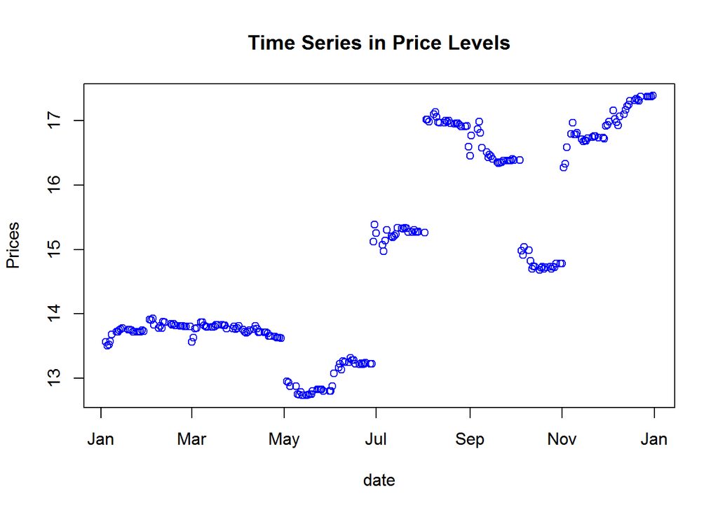

```r
raw.dates.2 = c("2016/1/5", "2016/1/6", "2016/1/7", "2016/1/8", "2016/1/11", "2016/1/12", "2016/1/13", "2016/1/14", "2016/1/15", "2016/1/19", "2016/1/20",
                 "2016/1/21", "2016/1/22", "2016/1/25", "2016/1/26", "2016/1/27", "2016/1/28", "2016/1/29", "2016/2/2", "2016/2/3", "2016/2/4", "2016/2/5", "2016/2/8",
                 "2016/2/9", "2016/2/10", "2016/2/11", "2016/2/12", "2016/2/16", "2016/2/17", "2016/2/18", "2016/2/19", "2016/2/22", "2016/2/23", "2016/2/24",
                 "2016/2/25", "2016/2/26", "2016/2/29", "2016/3/1", "2016/3/2", "2016/3/3", "2016/3/4", "2016/3/7", "2016/3/8", "2016/3/9", "2016/3/10", "2016/3/11", "2016/3/14",
                 "2016/3/15", "2016/3/16", "2016/3/17", "2016/3/18", "2016/3/21", "2016/3/22", "2016/3/23", "2016/3/24", "2016/3/28", "2016/3/29", "2016/3/30", "2016/3/31",
                 "2016/4/1", "2016/4/4", "2016/4/5", "2016/4/6", "2016/4/7", "2016/4/8", "2016/4/11", "2016/4/12", "2016/4/13", "2016/4/14", "2016/4/15", "2016/4/18", "2016/4/19", "2016/4/20",
                 "2016/4/21", "2016/4/22", "2016/4/25", "2016/4/26", "2016/4/27", "2016/4/28", "2016/4/29", "2016/5/3", "2016/5/4", "2016/5/5", "2016/5/9", "2016/5/10", "2016/5/11",
                 "2016/5/12", "2016/5/13", "2016/5/16", "2016/5/17", "2016/5/18", "2016/5/19", "2016/5/20", "2016/5/23", "2016/5/24", "2016/5/25", "2016/5/26", "2016/5/27",
                 "2016/5/31", "2016/6/1", "2016/6/2", "2016/6/3", "2016/6/6", "2016/6/7", "2016/6/8", "2016/6/9", "2016/6/10", "2016/6/13", "2016/6/14", "2016/6/15", "2016/6/16", "2016/6/17",
                 "2016/6/20", "2016/6/21", "2016/6/22", "2016/6/23", "2016/6/24", "2016/6/27", "2016/6/28", "2016/6/29", "2016/6/30", "2016/7/1", "2016/7/5", "2016/7/6", "2016/7/7", "2016/7/8",
                 "2016/7/11", "2016/7/12", "2016/7/13", "2016/7/14", "2016/7/15", "2016/7/18", "2016/7/19", "2016/7/20", "2016/7/21", "2016/7/22", "2016/7/25", "2016/7/26", "2016/7/27",
                 "2016/7/28", "2016/7/29", "2016/8/2", "2016/8/3", "2016/8/4", "2016/8/5", "2016/8/8", "2016/8/9", "2016/8/10", "2016/8/11", "2016/8/12", "2016/8/15", "2016/8/16", "2016/8/17", "2016/8/18",
                 "2016/8/19", "2016/8/22", "2016/8/23", "2016/8/24", "2016/8/25", "2016/8/26", "2016/8/29", "2016/8/30", "2016/8/31", "2016/9/1", "2016/9/2", "2016/9/6", "2016/9/7","2016/9/8", "2016/9/9",
                 "2016/9/12", "2016/9/13", "2016/9/14", "2016/9/15", "2016/9/16", "2016/9/19", "2016/9/20", "2016/9/21", "2016/9/22", "2016/9/23", "2016/9/26", "2016/9/27", "2016/9/28",
                 "2016/9/29", "2016/9/30", "2016/10/4", "2016/10/5", "2016/10/6", "2016/10/7", "2016/10/10", "2016/10/11", "2016/10/12", "2016/10/13", "2016/10/14", "2016/10/17", "2016/10/18", "2016/10/19",
                 "2016/10/20", "2016/10/21", "2016/10/24", "2016/10/25", "2016/10/26", "2016/10/27", "2016/10/28", "2016/10/31", "2016/11/1", "2016/11/2", "2016/11/3", "2016/11/4", "2016/11/7", "2016/11/8", "2016/11/9", "2016/11/10",
                 "2016/11/11", "2016/11/14", "2016/11/15", "2016/11/16", "2016/11/17", "2016/11/18", "2016/11/21", "2016/11/22", "2016/11/23", "2016/11/25", "2016/11/28", "2016/11/29", "2016/11/30", "2016/12/1",
                 "2016/12/2", "2016/12/5", "2016/12/6", "2016/12/7", "2016/12/8", "2016/12/9", "2016/12/12", "2016/12/13", "2016/12/14", "2016/12/15", "2016/12/16", "2016/12/19", "2016/12/20", "2016/12/21", "2016/12/22", "2016/12/23",
                 "2016/12/27", "2016/12/28", "2016/12/29", "2016/12/30", "2016/12/31")
dates.2 = as.Date(raw.dates.2)

plot(dates, raw.data$DL.Nearest.Settlement, xlab="date", ylab="Prices", main="Time Series in Price Levels", col="Blue")
lines(dates, raw.data$BJ.Nearest.Settlement, col="Yellow")
```

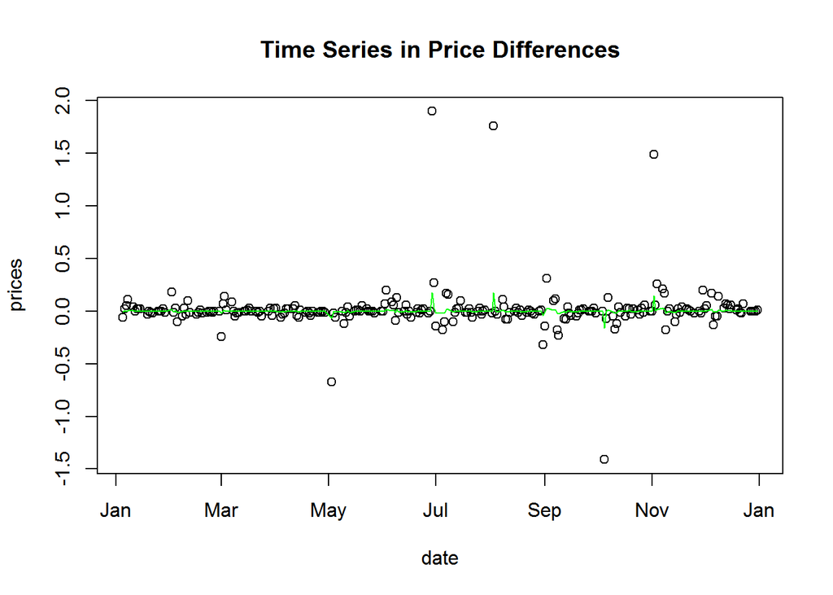

```r
plot(dates.2, dlfutures.diff, xlab="date", ylab="prices", main="Time Series in Price Differences")
lines(dates.2, bjfutures.diff, col="Green")
```

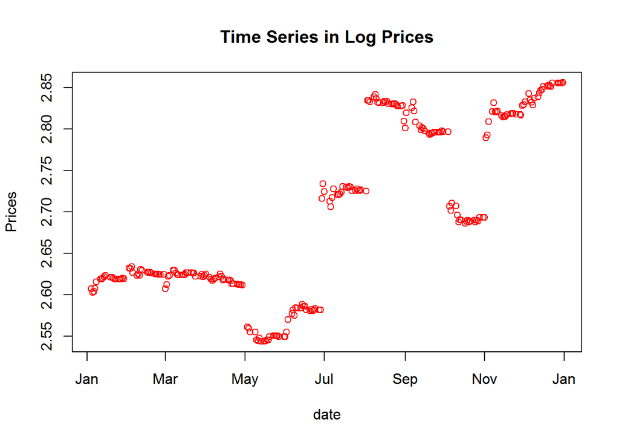

```r
plot(dates, ln.dlfutures, xlab="date", ylab="Prices", main="Time Series in Log Prices", col="Red")
lines(dates, ln.bjfutures)
```

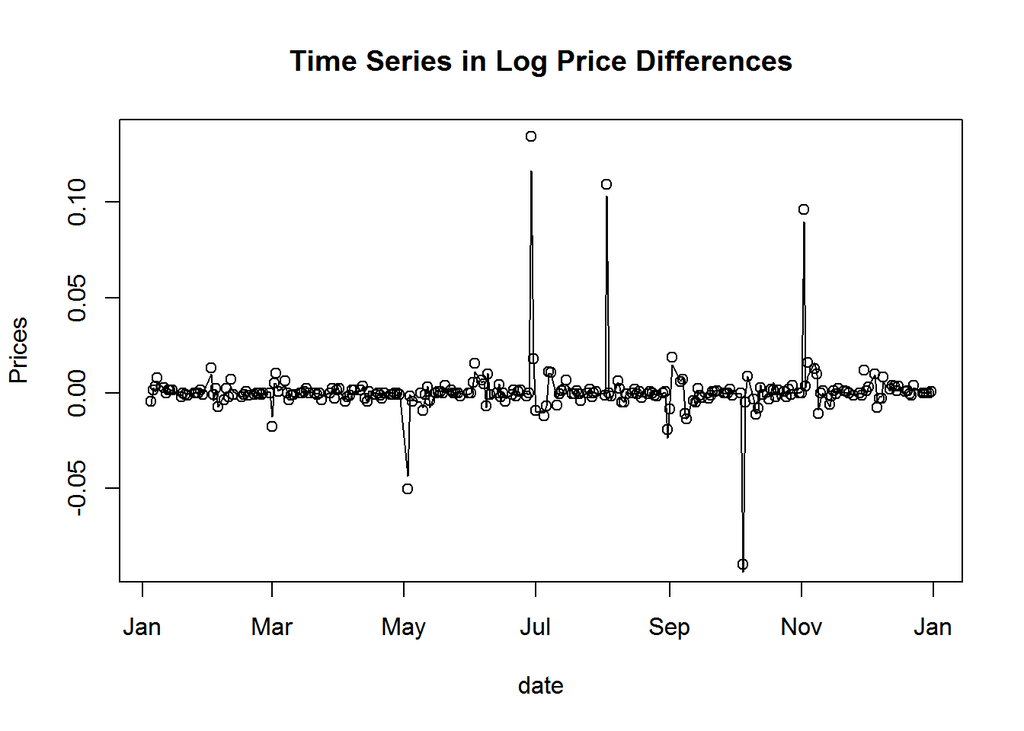

```r
plot(dates.2, ln.dlfutures.diff, xlab="date", ylab="Prices", main="Time Series in Log Price Differences")
lines(dates.2, ln.bjfutures.diff)
```

3. Carry out the Engle-Granger two-step procedure to test for co-integration between the series? What are the results? Are the series co-integrated? If so, what is the co-integrating vector? Carefully explain.

```r
fit <- lm(ln.dlfutures ~ ln.bjfutures)
summary(fit)
```

```
##
## Call:
## lm(formula = ln.dlfutures ~ ln.bjfutures)
##
## Residuals:
##       Min        1Q    Median        3Q       Max
## -0.019896 -0.007349 -0.003823  0.007909  0.024377
##
## Coefficients:
##              Estimate Std. Error t value Pr(>|t|)
## (Intercept)  2.121100   0.003902   543.6   <2e-16 ***
## ln.bjfutures 1.217658   0.008120   150.0   <2e-16 ***
## ---
## Signif. codes:  0 '***' 0.001 '**' 0.01 '*' 0.05 '.' 0.1 ' ' 1
##
## Residual standard error: 0.01066 on 246 degrees of freedom
## Multiple R-squared:  0.9892, Adjusted R-squared:  0.9891
## F-statistic: 2.249e+04 on 1 and 246 DF,  p-value: < 2.2e-16
```

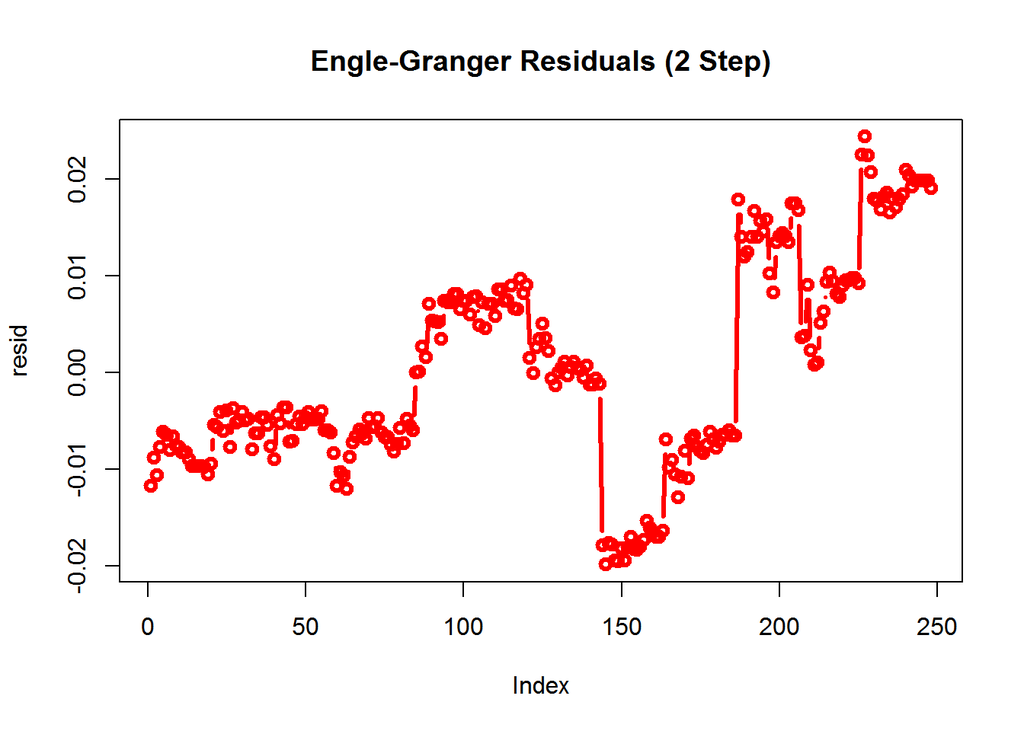

```r
par(mfrow = c(1,1))

resid <- fit$residuals
plot(resid, type = "b", lwd = 3, col = "red", main = "Engle-Granger Residuals (2 Step)")
```

```r
adf.resid <- ur.df(resid, type = "drift", selectlags = "BIC")
summary(adf.resid)
```

```
##
## ###############################################
## # Augmented Dickey-Fuller Test Unit Root Test #
## ###############################################
##
## Test regression drift
##
##
## Call:
## lm(formula = z.diff ~ z.lag.1 + 1 + z.diff.lag)
##
## Residuals:
##        Min         1Q     Median         3Q        Max
## -0.0169016 -0.0010840 -0.0001927  0.0009442  0.0241119
##
## Coefficients:
##               Estimate Std. Error t value Pr(>|t|)
## (Intercept)  0.0001239  0.0001873   0.661   0.5090
## z.lag.1     -0.0299852  0.0179269  -1.673   0.0957 .
## z.diff.lag  -0.0866545  0.0641343  -1.351   0.1779
## ---
## Signif. codes:  0 '***' 0.001 '**' 0.01 '*' 0.05 '.' 0.1 ' ' 1
##
## Residual standard error: 0.002934 on 243 degrees of freedom
## Multiple R-squared:  0.022,  Adjusted R-squared:  0.01395
## F-statistic: 2.733 on 2 and 243 DF,  p-value: 0.067
##
##
## Value of test-statistic is: -1.6726 1.6285
##
## Critical values for test statistics:
##       1pct  5pct 10pct
## tau2 -3.46 -2.88 -2.57
## phi1  6.52  4.63  3.81
```

[output not shown]

### The following information may be helpful as background information:

- Class III Milk is the so-called cheese milk. It is the main ingredient in cheese of all kinds. The Class III Milk price is regulated by the USDA.
- You find information about the regulated price here on the USDA’s website: {https://www.ams.usda.gov/resources/current-price-formulas}.
- The Class III Milk contract specification is found here: {http://www.cmegroup.com/trading/agricultural/dairy/class-iii-milk_contract_specifications.html}.
- The Cheese contract specification is found here: {http://www.cmegroup.com/trading/agricultural/dairy/cheese_contract_specifications.html}.

**3.** In this problem you will simulate values for spot prices and basis for heating oil and gasoline following the models of Bollen and Whaley in their paper *Simulating Supply* (which is in the readings file). Specifically, the follow models will be used:

**Spot Prices**

- $\ln{\left(\frac{S_{i,t}}{S_{i,t-1}}\right)} = \alpha_{i} (\beta_{i} - S_{i,t-1}) + \varepsilon_{i,t} \quad \mbox{for} \quad i = 1, 2$
- where $i=1$ for heating oil and $i=2$ for gasoline, and $(\varepsilon_{1,t}, \varepsilon_{2,t}) \sim BVN(0, \sigma_{1}^{2}, 0, \sigma_{2}^{2}, \rho)$. And $\rho$ is the correlation coefficient between heating oil and gas spot returns.

**Basis and Futures Prices**

- $b_{i,t} = \alpha_{i} b_{i,t-1} + \beta_{i} S_{i,t-1} + \varepsilon_{i,t} \quad \mbox{for} \quad i = 1,2$
- where again, $i = 1$ for heating oil and $i = 2$ for gasoline and $(\varepsilon_{1,t}, \varepsilon_{2,t}) \sim BVN(0, \sigma_{1}^{2}, 0, \sigma_{2}^{2}, \rho)$. Again, $\rho$ is the correlation between heating oil and gasoline basis.
- You can then obtain simulated futures prices as $F_{i,t} = S_{i,t}e^{b_{i,t}}$ for $i = 1,2$

With this as background, do the following:

1. Simulate 45 days of prices for spot and daily settlement prices for futures (via the basis equation). Looking at figure $1$ in the paper use initial values of $\$0.69$ for heating oil and $\$0.80$ for gasoline. Use an initial value for heating oil basis of $-0.02$ and $-0.01$ for gasoline. See Table $2$ in the paper for the other parameter values.

   ```
        Please see Excel sheet
   ```

2. Make time series plots labeling the x-axis as date and the y-axis as dollar prices. Assume a starting date of November 15, 1991. Plot spot prices, basis, and futures prices separately but combining the graphs for heating oil and gasoline together for each. Clearly label the series in each graph.

   ```
        Please see Excel Sheet
   ```

3. For the simulated 45-day period calculate the market-to-market cash flows. Assume and initial margin of $10\%$ and variation margin of $85\%$ of the initial margin. Assume a position of 1 contract for each position.

   ```
        Please see excel Sheet.
   ```

4. For the simulated 45-day period calculate a minimum-variance hedge ratio for both heating oil and unleaded gasoline.

   Please see excel sheet.

**4.** Describe the institutional differences between forward markets and futures markets. Describe the historical evolution of futures markets and the institutional features that define futures markets. Why have they developed the way they have? What market problems have they solved?

**Instiutional Differences** Futures contracts are essentially exchange-traded forward contracts." Futures contracts are standardized and are more specific on delivery. The main institutional differences are:

+Futures are settled daily while forwards are settled at expiration.

+With daily settlement, futures are liquid since you can take opposite position to “get out” of the obligation.

+OTC forward contracts can be customizable whereas futures contracts are standardized and are more specific on delivery.

+Forward contracts suffer from credit risk while futures contracts are constructed in such a way to minimize credit risk. Futures have a clearing house which essentially prevents default of either party.

+Future markets usually have daily price limits.

+Forward contracts are private transactions while futures are not and are reported to the futures exchange. Futures are government regulated while forwards are not.

**Historical Evolution**

Contracts have been used by individuals to fix the price of commodities to be delivered in future forever. The first documented cases of these contracts being used dates back to Greek and Roman marketplaces. This shows us how futures contracts came to life:[he futures contract, as we know it today, evolved as farmers (sellers) and dealers (buyers) began to commit to future exchanges of grain for cash. For instance, the farmer would agree with the dealer on a price to deliver to him 5,000 bushels of wheat at the end of June. The bargain suited both parties. The farmer knew how much he would be paid for his wheat, and the dealer knew his costs in advance. The two parties may have exchanged a written contract to this effect and even a small amount of money representing a “guarantee.” Such contracts became common and were even used as collateral for bank loans. They also began to change hands before the delivery date. If the dealer decided he didn’t want the wheat, he would sell the contract to someone who did. Or, the farmer who didn’t want to deliver his wheat might pass his obligation on to another farmer The price would go up and down depending on what was happening in the wheat market. If bad weather had come, the people who had contracted to sell wheat would hold more valuable contracts because the supply would be lower; if the harvest were bigger than expected, the seller’s contract would become less valuable. It wasn’t long before people who had no intention of ever buying or selling wheat began trading the contracts. They were speculators, hoping to buy low and sell high or sell high and buy low.](http://futures.tradingcharts.com/tafm/tafm1.html)

**Institutional Features**

In a futures contract there are two parties:

The long position, or buyer, agrees to purchase the underlying at a later date or at the expiration date at a price that is agreed to at the beginning of the transaction. Buyers benefit from price increases. The short position, or seller, agrees to sell the underlying at a later date or at the expiration date at a price that is agreed to at the beginning of the transaction. Sellers benefit from price decreases. Prices change daily in the marketplace and are market to market on a daily basis.

At expiration, the buyer takes delivery of the underlying from the seller or the parties can agree to make a cash settlement. Usually, the buyer/seller would take an offsetting position if they did not wish to take delivery or deliver.

**5.** Consider the paper that was presented in class by Liu titled *Price Relations Among Hog, Corn, and Soybean Meal Futures*.

1. What were the main empirical findings of the paper? What statistical and econometric methods were used by the author? Were you persuaded by author’s evidence?

       Liu used multivariate co-integration, error correction, stationary(mean reversion), unit root test as his main statistical and econometric methods to support/prove his findings.

2. At the beginning of the course we read the appendix on the history of thought on equilibrium concepts in economics from Culp’s book *Risk Transfer*, in which the author states, “it becomes quite hard to explain a lot of financial and derivatives market activity without being a *little bit* Austrian.” How does that idea apply to the empirical findings of Liu? Do you think that statement is true? Can you give Liu’s econometric model (the error-correction model) a neo-Austrian interpretation?

3. At the end of the paper Liu conducts some trading simulations. Outline the methodology that Liu uses to conduct these trading simulations. Why is that necessary? Do you find the simulations convincing? Would you place real money on his trading model? If not, what would it take to convince you that the model really is predictive of abnormal profits?

**6.** In class we discussed the case of oil hedging by Metalgesellschaft (MG). In their paper *Metalgesellschaft and the Economics of Synthetic Storage* Culp and Miller defended MG’s hedging strategy. Pirrong strongly criticized Culp and Miller’s findings in his paper *Metalgesellschaft: Prudent Hedger Ruined, or a Wildcatter on NYMEX?*. Please answer the following questions about the debate over MG’s hedging strategy.

1. Culp & Miller called MG’s main hedging strategy *Synthetic Storage*. Please outline the basics of this strategy, and explain how it differs from risk minimizing hedging. In your explanation, you may want to reference the ideas of the economist Holbrook Working cited by Culp & Miller regarding hedging strategies and the motives for hedging.

2. One of the main points of disagreement between Culp & Miller and their critics, especially Pirrong, is over the proper hedge ratio for MG’s hedging strategy. What do you think the correct hedge ratio was for MG? Can you outline an empirical strategy for estimating the proper hedge ratio? Explain.

3. At the end of his paper, Pirrong states “Given the huge losses incurred in late 1993, a Bayesian estimating the probability distribution of MG’s information advantage would almost certainly place little weight on the possibility that the firm was well informed, and great weight on the possibility that it did not possess superior information, regardless of the charitably of his priors concerning the prescience of MG’s managers.” Why do you think Pirrong invokes Bayes’ Rule? Comment on this statement by Pirrong.

4. Energy markets such as the oil market are often historically characterized by backwardation, but have also had long periods of contango. Does that matter for MG’s synthetic storage strategy? Explain.

5. In answering these questions you may want to also reference other papers, such as any of the other readings that we have done in class (Hayek, Nau, Grossman & Stiglitz, etc). Additionally, I will place two other papers related to this question in the readings files. The first is *Rethinking Risk Management* by Rene Stulz, and the second is *Simulating Supply* by Bollen and Whaley. These are not necessarily required, but you may find them helpful in framing the discussion and your answers.

   ```
       Not Required
   ```

**7.** Consider the following two papers:

1. *Orange Juice and Weather* by Richard Roll.
2. *Is Sound Just Noise?* by Coval & Shumway.

Both papers deal with the informational role of prices in a market setting. Relate the findings of each paper to the main idea in Hayek’s paper *The Use of Knowledge in Society*. Does the evidence in the article support Hayek’s main thesis? If so, how? Explain. Be careful to give an economic interpretation to any statistical or econometric measure used in the article. Also, explain the data that were used in the respective study.

In order to relate the findings of Richard Roll and Coval & Shumway to Hayeks paper, *The Use of Knowledge in Society*, it is essential that we fully understand the main points of Hayeks paper. The main points of _The Use of Knowledge in Society are: - The complete knowledge of society is not possessed by one person and cannot be possessed either - Information in society is always being updated and is not absolute or complete. - The price system(markets) solves these issues - Every price represents indicates knowledge. - A person only really needs to know the price of a given commodity to make rational decisions. - The example of how a Number two pencil is made is great example of this.

Now, we have a basic understanding of Hayeks main points; we can start to relate the findings of Richard Roll and Coval & Shumway.

Richard Roll find that prices and returns on orange juice futures predict the weather better than National Weather Service, who accurately and consistently reports the weather. This backs Hayek’s idea that prices reflect all available information in prices. Hence, markets are efficient. Roll finds that when limits were placed on price changes(movements), the market became insufficient, so the prices were not reflecting all available information in the market, which in turn did lost it predicting power of weather. As you can see, the evidence and findings of Richard Roll fully support Hayeks main thesis.

Roll finds relatively high volatility in the returns on frozen orange juice futures. What I found especially interesting was that, Roll discovers that weather influences the orange crop, but it only explains a small portion of volatility in frozen orange juice returns. Again, markets are efficient and incorporate all available information.

Roll used daily frozen orange juice futures contract prices from October 1975 through December 1981 since weather data was only available after October 1975. Only two contract maturities were used, 2-4 months and 4-6 months to maturity. Equally weighted average of daily returns on the above mentioned contracts were used.

Coval and Shumway found that the sound level in the Chicago Board of Trade’s 30 year Treasury Bond futures trading pit convey information that this very important to market efficiency. This noise includes non-verbal communication like: traders jumping up and down, hand signals, etc… Coval and Shumway found that a lot of this information is lost in electronic trading, the pit adds important information for market efficiency. In particular, sound levels were high right after the market opened and at close, price changes and trading volume. Hence, there is a correlation between these variables and high noise. This further supports Hayeks thesis.

Coval and Shumway placed a microphone in the pit for 2 months. They took second by second recording and matched it with data of prices and trading volume from the Chicago Board of Trade. In turn, they used this data to do their analysis.

**8.** Read the paper *Futures markets, Bayesian forecasting and risk modeling* by Quintana, Carvalho, Scott, and Costigliola. Relate the main idea of the paper to the articles *The Use of Knowledge in Society* by Hayek and *Arbitrage, Rationality, and Equilibrium* by Nau and McCardle. I once stated in class that Nau’s *Arbitrage Choice Theory* is the direct result of when a thoughtful Bayesian reads and understands Hayek. Can we interpret the Quintana et al paper in the same light (i.e. Bayesians taking Hayek seriously)? Explain.

[output not shown]

- Weather derivatives are traded on many exchanges, including the CME: {http://www.cmegroup.com/trading/weather/}.
- The Baltic Exchange in London is organized around the shipping industry and shipping risk management. The main contract is futures contract called Forward Freight Agreements or FFAs. The exchange website is here: {https://www.balticexchange.com/}. The wikipedia article is also helpful: {https://en.wikipedia.org/wiki/Baltic_Exchange}.
- In a partnership with the NASDAQ Financial exchange The New York Interactive Advertising Exchange for ad futures is starting up: [link]{https://www.nyiax.com/}. See also the wikipedia article on ad exchanges for background: [link]{https://en.wikipedia.org/wiki/Ad_exchange}.
- Helyette Geman, a world expert in commodity markets and commodity derivatives, has written in her paper (with coauthor) titled how water might someday be traded as other commodities are such as oil, coffee, etc. (The paper in the readings folder).

Comment on what you think will be the shape of innovations in derivatives markets in the next two decades. What things that are not now traded on exchanges, or with derivatives do you think will be? How will this facilitate global commerce? Outline a business strategy that does not now exist that you think someday might soon exist if derivatives markets are created. What is the role for data and data analysis in your proposal?

I think derivatives will be more widely used. We will see derivatives on health, water, sports, mortgages, salary, labor etc.. Over my lifetime, I have gotten the sense that people in general think/believe derivatives are dangerous, scary, and difficult to understand. This general misconception will dissipate over time. This will lead to derivatives revolution that I mentioned earlier.

One thing that is not currently traded on any exchange that I know of is water. Water is an essential commodity to every person, plant, animal and thing. This will lead to water being traded in order to allocate it efficiently. Many places, including countries, will need to trade with other countries to get enough water for their needs. This will lead to global commerce. Derivatives, especially, facilitate trade. People will have to go to “bigger pools” to hedge away their risk which in turn facilitates global commerce.

If derivative markets are created on water. We could implement the idea from Liu’s paper of *Price Relations Among Hog, Corn, and Soybean Meal Futures*. Find securities that are co-integrated with water, which seems like everything, find the long run equilibrium and trade on the basis.

The role for data and data analysis is that it allows us to find the long run equilibrium and look for trading patterns. Having more information, more data, more analysis would allow us to price the derivatives appropriately and include all relevant information. That is the beauty of data, you can bring so much information to one location that I don’t think Hayek could even fathom. That is why I believe data, and data analyst will become more valuable over time.